# Homework 1.1

- Show All Code
- Hide All Code
- View Source

Author

Affiliation

David Sneddon

Old Dominion University

## Question 1

Copy and paste the following vector into R: `vec <- sample(1:100, 10, FALSE)`. Use this vector for the following.

1. Print `vec` to the console. (**2 Points**)

```r
#saves a random 10 element vector
vec <- sample(1:100, 10, FALSE)
#outputs to console
vec
```

**Output**

```
 [1] 34 55 35 80 83 43  3 52 40 64
```

2. Print the first 5 elements of `vec`. (**2 Points**)

```r
#outputs vector to console
vec[1:5]
```

**Output**

```
[1] 34 55 35 80 83
```

3. Print the last 3 elements of `vec`. (**2 Points**)

```r
#finds the last three elements by taking the
#length of the vector then outputting from two positions to the left to the end
vec[(length(vec)-2):length(vec)]
```

**Output**

```
[1] 52 40 64
```

4. Print the 3rd and 8th elements of `vec`. (**3 Points**)

```r
#prints the 3rd and 8th elements
vec[c(3,8)]
```

**Output**

```
[1] 35 52
```

5. Print the elements of `vec` that are larger than 50. (**3 Points**)

```r
#outputs a subset of elements greater than 50
vec[vec>50]
```

**Output**

```
[1] 55 80 83 52 64
```

6. Print the elements of `vec` that are odd (not divisible by two). (**3 Points**)

```r
#uses the modulus operator "%%" and subsets all instances where the modulus (remainder)
#is not zero when divided by two
vec[vec %% 2 != 0]
```

**Output**

```
[1] 55 35 83 43  3
```

## Question 2

Use these data on drinking and wages from Elderton and Pearson (1910) (data; [documentation](https://vincentarelbundock.github.io/Rdatasets/doc/HistData/DrinksWages.html)) for the following.

1. Read in the data using `read.csv()` and store it as `DrinksWages`.[^1] (**1 Point**)

```r
#reads the data
DrinksWages <- read.csv("https://vincentarelbundock.github.io/Rdatasets/csv/HistData/DrinksWages.csv")
```

2. Print the column names of `DrinksWages`. (**1 Point**)

```r
#outputs the columnn names
colnames(DrinksWages)
```

**Output**

```
[1] "rownames" "class"    "trade"    "sober"    "drinks"   "wage"     "n"
```

3. What type of measurement (Nominal, Ordinal, Interval, or Ratio) is `sober`? Explain why. (**2 Points**)

This is a ratio measurement. It has a natural zero. If the value for a particular trade is zero, it means that everyone in the sample drinks alcohol for that trade. There is a also a meaningful difference in the ratio between two measurements.

4. What fraction (or as a percentage) of observations of the wage variable are larger than 30? (**2 Points**)

```r
#outputs a decimal form of the percentage
sum(DrinksWages$wage>30) / nrow(DrinksWages)
#outputs a concatenated string of characters to express as a fraction
paste0(sum(DrinksWages$wage>30),"/", nrow(DrinksWages))
#outputs a concatenated string of characters to express as a percentage
#to two decimal places
paste0(round(sum(DrinksWages$wage>30) / nrow(DrinksWages)*100,2),"%")
```

**Output**

```
[1] 0.3285714
[1] "23/70"
[1] "32.86%"
```

5. Create a new variable inside `DrinksWages` called `total`. This variable should reflect the sum of the two variables `sober` and `drinks` for each observation. (**2 Points**)

```r
#adds the two columns "total" should == "n"
DrinksWages["total"] <- DrinksWages$sober + DrinksWages$drinks
```

6. Create a new variable inside `DrinksWages` called `x`. This variable should be `drinks` divided by `total`. In words, how can we interpret what `x` represents? (**3 Points**)

```r
#divides the two columns
DrinksWages["x"] <- DrinksWages$drinks / DrinksWages$total
```

This is a ratio of drinkers to each sampled profession.

7. Plot `x` on the $X$-axis and wages on the $Y$-axis. Each point should be colored based on their `class` value[^2]. Use `pch = 19`. Label your axes appropriately and include a legend. (**4 Points**)

```r
#Set black as an initial placeholder helpful for error checking
DrinksWages["point_color"] <- "black"

#Sets colors to each "class"
DrinksWages$point_color[DrinksWages$class == 'A'] <- "blue"
DrinksWages$point_color[DrinksWages$class == 'B'] <- "red"
DrinksWages$point_color[DrinksWages$class == 'C'] <- "green"

#Plots the data
plot(DrinksWages$x,DrinksWages$wage,
     pch = 19,
     col = DrinksWages$point_color,
     main = "Ratio of Drinkers vs Average Wage",
     xlab = "% of Drinkers",
     ylab = "Average Wage")
#Adds a legend: Positioning was a bit difficult so I reduced the size of the legend by adjusting cex down.
legend("topright",
       pch = 19,
       bty = "o",
       cex = 0.75,
       horiz = FALSE,
       legend = paste("Class", unique(DrinksWages$class)),
       col = unique(DrinksWages$point_color))
```

**Plot**

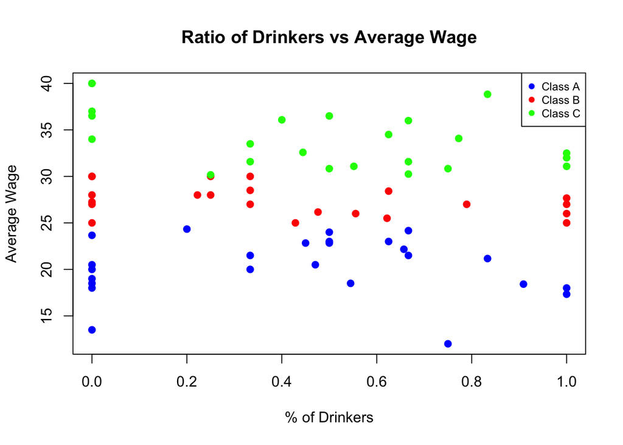

## Question 3

**This one is challenging.** [This `.pdf` file](https://www.erikthered.com/tutor/historical-average-SAT-scores.pdf) contains SAT scores over time for men and women. Unfortunately, when I copied it into a `.csv`, the formatting got messed up.[^3]

1. Recreate the table format of the PDF with [`sat2.csv`](https://alexcardazzi.github.io/econ311/data/sat2.csv) as a `data.frame`.[^4] Rename the year and total math columns (the first one) to `year` and `total_math`. (**6 Points**)

```r
#Reads the data
sat2 <- read.csv("https://alexcardazzi.github.io/econ311/data/sat2.csv")
#I couldn't find any other way to build the matrix without this line.
sat2 <- unlist(sat2)
#Turns the data into a matrix
sat2 <- matrix(sat2, nrow = length(sat2)/16, ncol = 16, byrow = TRUE )
#Turns the data into a data frame, left the others unnamed, although simply
#not adding them would have been sufficient as they will be removed later.
sat2 <- data.frame(year = sat2[,1],
                     sat2[,2:4],
                     total_math = sat2[,5],
                     sat2[,6:ncol(sat2)])
```

2. Convert the total math variable into a numeric variable. This step will likely create some `NA` values in the variable, so remove the rows where total math is missing. (**4 Points**)

```r
#Changes the values to numeric
sat2$total_math <- as.numeric(sat2$total_math)
#Removes the rows with NA
sat2 <- sat2[!is.na(sat2$total_math),]
```

3. Finally, remove all of the columns *except* `year` and `total_math` from the dataset. (**4 Points**)

```r
#Keeps only the two named columns
sat2 <- sat2[,c("year","total_math")]
```

4. Make a plot with two lines. On the $X$-axis should be year and on the $Y$-axis should be total math. The first line should be SAT scores from the beginning of the sample until 1999, and another from 2000 and onwards. The two lines should be different colors. Be sure to label the axes and include a legend. (**6 Points**)

```r
#Plots the data
plot(sat2$year, sat2$total_math,
     las = 1,
     type = "n", #Makes the points invisible
     xlab = "Year",
     ylab = "Total Math",
     main = "SAT Total Math - Annual Averages")
#Creates lines for Pre 2000 and Post 2000 (inclusive)
lines(sat2$year[as.numeric(sat2$year) <= 1999],
      sat2$total_math[as.numeric(sat2$year) <= 1999],
      col = 2)
lines(sat2$year[as.numeric(sat2$year) > 1999],
      sat2$total_math[as.numeric(sat2$year) > 1999],
      col = 4)
#Creates the legend
legend("bottomright",
       legend = c("Pre 2000","Post 2000"),
       bty = "n",
       col = c(2,4),
       lty = 1,
       cex = 0.75)
```

**Plot**

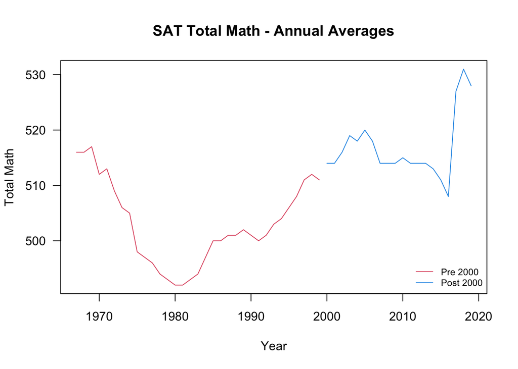

## Footnotes

[^1]: **Hint**: you can use either the hyperlink’s URL *or* you can click on the hyperlink, download the file, and read it in via file path. Also, you might find it helpful to read through the data’s documentation so you know what the different columns/variables mean.
[^2]: You are free to choose whatever colors you’d like, but please avoid using “yellow” for the sake of our eyes. It’s blindly bright against the white background.
[^3]: You’ll run into this a lot when working with `.pdf` files, so avoid them!
[^4]: **Hint**: After you read in the data, try printing it to your console. You should see one long vector. Try reorganizing the vector into a matrix, and then the matrix into a `data.frame`.